# Simulation: greedy forward parameter selection

Thomas Wilschut Last updated: 2026-10-01

- Setup
- Simulate response data
- Greedy forward parameter selection (C++ likelihood)
- Greedy fits plot (Figure 4)
- AIC plot (Figure 3)
- Stepwise decomposition of the AIC plot (for slides)
- Session info

This markdown file is can be used to reproduce the results reported in the paper: Idiographic Memory Modelling in ACT-R using Alternating Maximum Likelihood Estimation

This script is used for the greedy selection procedure, reported in the section: Simulation: Recovering parameters from synthetic data.

# Setup

```r
library(data.table)
library(here)
library(ggplot2)
library(furrr)
library(patchwork)
library(ggsci)
library(Rcpp)
library(ggh4x)
library(tidyverse)
library(svglite)

# Parallel backend
plan(multisession, workers = availableCores() - 1)

# Source simulation + fitting functions (which also compile actr_ll.cpp)
source(here::here("R", "sim-mle.R"))

# Plot aesthetics
col_blue <- "#0571b0"
col_red  <- "#ca0020"
plottheme <- theme_bw(base_size = 12)
```

# Simulate response data

We generate a single synthetic dataset (50 learners, 15 facts, 10 repetitions per fact) with a fixed seed. The same `sim` object is reused throughout this notebook, both as the input to the greedy selection and as the source of the ground-truth parameter values for the recovery plot.

```r
sim <- simulate_fact_learner_data(
  n_learners    = 50,
  n_facts       = 15,
  n_repetitions = 10,
  seed          = 999
)
```

[output not shown]

# Greedy forward parameter selection (C++ likelihood)

The greedy procedure starts with no free participant-level parameters (only fact-level offsets Δφ are estimated). At each step it adds the candidate parameter that produces the largest AIC improvement, fitting all learners in parallel using the compiled C++ likelihood from `actr_ll.cpp`.

```r
greedy_results <- greedy_select_params(
  sim_full   = sim,
  n_reps     = 10,
  n_facts    = 15,
  all_params = c("phi", "tau", "s", "F", "ter")
)

# This step is expensive (it refits every learner at every candidate parameter),
# so the chunk is set to eval = FALSE; the result is cached and reloaded below.
# Set eval = TRUE (or delete the cached .rds) to rerun it from scratch.
saveRDS(greedy_results, here::here("data", "processed", "fits", "results_greedy_selection.rds"))
```

# Greedy fits plot (Figure 4)

[figure not shown]

```r
greedy_results <- readRDS(here::here("data", "processed", "fits", "results_greedy_selection.rds"))
greedy_fits    <- greedy_results$learner_fits
greedy_summary <- greedy_results$summary

# Backward compatibility: rename old column names from pre-phi cached fits
greedy_fits    <- as.data.table(greedy_fits)
greedy_summary <- as.data.table(greedy_summary)
if ("alpha" %in% names(greedy_fits))    setnames(greedy_fits,    "alpha", "phi")
if ("alpha" %in% names(greedy_summary)) setnames(greedy_summary, "alpha", "phi")
if ("param_added" %in% names(greedy_fits))    greedy_fits[param_added    == "alpha", param_added := "phi"]
if ("param_added" %in% names(greedy_summary)) greedy_summary[param_added == "alpha", param_added := "phi"]

true_params <- sim[is_study == FALSE, .(
  true_phi = true_phi[1],
  true_tau = true_tau[1],
  true_s   = true_s[1],
  true_F   = true_lf[1],
  true_ter = true_ter[1]
), by = user_id]

greedy_fits_m <- merge(as.data.frame(greedy_fits), as.data.frame(true_params), by = "user_id")

selected_models <- as.data.frame(greedy_summary[selected == TRUE][order(step)])
selection_order <- selected_models$param_added

param_info <- data.frame(
  free_name = c("phi", "tau", "s", "F", "ter"),
  fit_col   = c("phi", "tau", "s", "lf", "ter"),
  true_col  = c("true_phi", "true_tau", "true_s", "true_F", "true_ter"),
  label     = c("Speed of Forgetting", "Retrieval threshold",
                "Activation noise", "Latency factor", "Non-retrieval time"),
  stringsAsFactors = FALSE
)

name_lookup <- setNames(param_info$label, param_info$free_name)
slabels     <- paste0("Step ", selected_models$step, ": winner = ", name_lookup[selected_models$param_added])
col_order   <- param_info$label[match(selection_order, param_info$free_name)]

# Build plot data
plot_rows <- list()
for (s in seq_along(slabels)) {
  sel_cand     <- selected_models$param_added[s]
  free_at_step <- selection_order[1:s]
  step_fits    <- greedy_fits_m[greedy_fits_m$step == s, ]
  candidates   <- unique(step_fits$param_added)

  for (i in seq_len(nrow(param_info))) {
    pname <- param_info$free_name[i]

    if (pname %in% free_at_step) {
      source_fits <- step_fits[step_fits$param_added == sel_cand, ]
      status <- "selected"
    } else if (pname %in% candidates) {
      source_fits <- step_fits[step_fits$param_added == pname, ]
      status <- "candidate"
    } else {
      next
    }

    plot_rows[[length(plot_rows) + 1]] <- data.frame(
      step       = s,
      step_label = slabels[s],
      param      = param_info$label[i],
      estimate   = source_fits[[param_info$fit_col[i]]],
      true_value = source_fits[[param_info$true_col[i]]],
      status     = status,
      user_id    = source_fits$user_id,
      stringsAsFactors = FALSE
    )
  }
}
plot_df <- do.call(rbind, plot_rows)

# Filter outliers
plot_df <- plot_df[plot_df$estimate <= 3, ]

# Compute correlations
corr_labels <- plot_df %>%
  group_by(param, step_label, status) %>%
  summarise(r = cor(estimate, true_value, use = "complete.obs"), .groups = "drop") %>%
  mutate(r_lab = paste0("r = ", format(round(r, 2), nsmall = 2)))

# Factor ordering
plot_df$param     <- factor(plot_df$param, levels = col_order)
corr_labels$param <- factor(corr_labels$param, levels = col_order)

# Build one row of panels per step, each with its own free scales and title
row_plots <- list()
for (s in seq_along(slabels)) {
  df_s   <- plot_df[plot_df$step == s, ]
  corr_s <- corr_labels[corr_labels$step_label == slabels[s], ]

  row_plots[[s]] <- ggplot(df_s, aes(x = true_value, y = estimate)) +
    geom_point(aes(color = status), alpha = 0.6, size = 1.5) +
    scale_color_manual(
      values = c("selected" = "#0571b0", "candidate" = "grey60"),
      labels = c("selected" = "Selected", "candidate" = "Not selected"),
      limits = c("candidate", "selected"),
      drop   = FALSE,
      name   = ""
    ) +
    geom_smooth(method = "lm", se = TRUE, aes(linetype = status),
                color = "black", linewidth = 0.6, show.legend = FALSE) +
    scale_linetype_manual(values = c("selected" = "solid", "candidate" = "dashed")) +
    geom_abline(slope = 1, intercept = 0, linetype = "dotted", color = "grey40") +
    geom_text(data = corr_s,
              aes(x = -Inf, y = Inf, label = r_lab, color = status),
              inherit.aes = FALSE, hjust = -0.1, vjust = 1.5, size = 3.5,
              show.legend = FALSE) +
    facet_wrap(~ param, scales = "free", nrow = 1) +
    guides(color = if (s == 1) "legend" else "none") +
    labs(title = slabels[s], x = "True value", y = "Recovered value") +
    plottheme +
    theme(
      strip.text  = element_text(size = 8),
      plot.title  = element_text(face = "bold", size = 10, hjust = 0),
      panel.spacing = unit(0.3, "lines")
    )
}

p_grid <- wrap_plots(row_plots, ncol = 1) +
  plot_layout(guides = "collect", axis_titles = "collect") &
  theme(legend.position = "bottom")

p_grid
```

```r
# Paper Figure 4: parameter recovery at each step of the greedy forward selection
ggsave(here::here("output", "greedy_recovery_grid.png"), p_grid, width = 10, height = 10)
```

# AIC plot (Figure 3)

This reproduces Figure 3: the AIC at each step of the greedy forward selection. The solid line traces the selected path (the lowest-AIC candidate at each step), while the faint points show the alternative candidates that were not selected. A signed square-root transform is applied to the y-axis so that both the very large step-1 values and the small differences at later steps remain legible in a single panel.

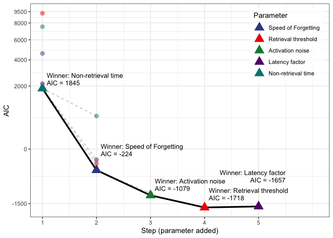

```r
greedy_summary <- as.data.table(greedy_results$summary)
if ("param_added" %in% names(greedy_summary)) greedy_summary[param_added == "alpha", param_added := "phi"]
param_display <- c(
  phi = "Speed of Forgetting",
  tau = "Retrieval threshold",
  s   = "Activation noise",
  F   = "Latency factor",
  ter = "Non-retrieval time"
)

greedy_summary[, param_label := param_display[param_added]]

# Fix legend order to phi, tau, s, F, ter
param_order <- param_display[c("phi", "tau", "s", "F", "ter")]
greedy_summary[, param_label := factor(param_label, levels = param_order)]

selection_path <- greedy_summary[selected == TRUE][order(step)]
selection_path[, win_label := sprintf("Winner: %s\nAIC = %.0f", as.character(param_label), total_aic)]
selection_path[, lbl_x     := step + ifelse(step == max(step), 0.5, 0.08)]
selection_path[, lbl_hjust := ifelse(step == max(step), 1, 0)]
selection_path[, lbl_y     := total_aic + fifelse(step == 4, 400,
                                          fifelse(step == 5, 1100, 200))]
param_cols <- setNames(pal_aaas()(5), param_order)

seg_data <- greedy_summary[selected == FALSE]
seg_data[, y_from := selection_path$total_aic[match(step - 1, selection_path$step)]]

aic_vals <- greedy_summary$total_aic
sqrt_trans <- scales::trans_new(
  name      = "signed_sqrt",
  transform = function(x) sign(x) * sqrt(abs(x)),
  inverse   = function(x) sign(x) * x^2
)
aic_breaks <- sort(unique(c(
  round(min(aic_vals) / 500) * 500,
  seq(0, max(aic_vals), by = 2000),
  round(max(aic_vals) / 500) * 500
)))

p_aic <- ggplot() +
  geom_segment(data = seg_data[!is.na(y_from)],
               aes(x = step - 1, xend = step, y = y_from, yend = total_aic),
               linewidth = 0.4, color = "grey70", linetype = "dashed") +
  geom_line(data = selection_path,
            aes(x = step, y = total_aic),
            linewidth = 1.2, color = "black") +
  geom_point(data = greedy_summary[selected == FALSE],
             aes(x = step, y = total_aic, color = param_label),
             size = 3, shape = 16, alpha = 0.5) +
  geom_point(data = selection_path,
             aes(x = step, y = total_aic, color = param_label),
             size = 5, shape = 17) +
  geom_text(data = selection_path,
            aes(x = lbl_x, y = lbl_y, label = win_label, hjust = lbl_hjust),
            vjust = 0, size = 3.5, lineheight = 0.95, color = "black") +
  scale_color_manual(name = "Parameter", values = param_cols) +
  scale_y_continuous(trans = sqrt_trans, breaks = aic_breaks) +
  scale_x_continuous(breaks = 1:5, expand = expansion(mult = c(0.05, 0.18))) +
  labs(x = "Step (parameter added)", y = "AIC") +
  theme_bw() +
  theme(legend.position = c(0.98, 0.98),
        legend.justification = c("right", "top"),
        legend.background = element_rect(fill = alpha("white", 0.7), color = NA))
p_aic
```

```r
# Paper Figure 3: greedy forward parameter selection based on AIC
ggsave(here::here("output", "greedy_selection_aic.png"), p_aic, width = 8, height = 6)
```

# Stepwise decomposition of the AIC plot (for slides)

Export the greedy-selection AIC plot one step at a time, each cumulative: step 1 shows only the first winner, step 2 reveals steps 1–2, etc. The x-axis and y-axis are fixed to the full-data range so nothing jumps between slides.

```r
dir.create(here::here("output", "greedy_stepwise"), showWarnings = FALSE)

# Full axis ranges (computed from the complete data, kept fixed across steps)
x_range <- c(1, 5)
y_range <- range(greedy_summary$total_aic)

n_steps <- max(greedy_summary$step)

for (i in 0:n_steps) {
  gs_i   <- greedy_summary[step <= i]
  sp_i   <- selection_path[step <= i]
  seg_i  <- seg_data[step <= i & !is.na(y_from)]

  p_step <- ggplot() +
    geom_segment(data = seg_i,
                 aes(x = step - 1, xend = step, y = y_from, yend = total_aic),
                 linewidth = 0.4, color = "grey70", linetype = "dashed") +
    geom_line(data = sp_i,
              aes(x = step, y = total_aic),
              linewidth = 1.2, color = "black") +
    geom_point(data = gs_i[gs_i$selected == FALSE, ],
               aes(x = step, y = total_aic, color = param_label),
               size = 3, shape = 16, alpha = 0.5) +
    geom_point(data = sp_i,
               aes(x = step, y = total_aic, color = param_label),
               size = 5, shape = 17) +
    geom_text(data = sp_i,
              aes(x = lbl_x, y = lbl_y, label = win_label, hjust = lbl_hjust),
              vjust = 0, size = 5, lineheight = 0.95, color = "black") +
    scale_color_manual(name = "Parameter", values = param_cols,
                       drop = FALSE, limits = names(param_cols)) +
    scale_y_continuous(trans = sqrt_trans, breaks = aic_breaks) +
    scale_x_continuous(breaks = 1:5,
                       limits = x_range,
                       expand = expansion(mult = c(0.05, 0.18))) +
    coord_cartesian(ylim = y_range) +
    labs(x = "Step (parameter added)", y = "AIC") +
    theme_bw(base_size = 15) +
    theme(legend.position      = c(0.98, 0.98),
          legend.justification = c("right", "top"),
          legend.background    = element_rect(fill = alpha("white", 0.7), color = NA))

  prefix <- sprintf("step_%02d", i)
  ggsave(here::here("output", "greedy_stepwise", paste0(prefix, "_aic.png")),
         p_step, width = 8, height = 6, dpi = 150)
  ggsave(here::here("output", "greedy_stepwise", paste0(prefix, "_aic.svg")),
         p_step, width = 8, height = 6)

  cat(sprintf("Exported AIC step %d/%d\n", i, n_steps))
}
```

```
## Exported AIC step 0/5

## Exported AIC step 1/5

## Exported AIC step 2/5

## Exported AIC step 3/5

## Exported AIC step 4/5

## Exported AIC step 5/5
```